# Part II - Prosper Loan

## by Ismail Essagar

> **Before you start**: You must have the README.md file ready that include a summary of main findings that reflects on the steps taken during the data exploration (Part I notebook). The README.md file should also describes the key insights that will be conveyed by the explanatory slide deck (Part II outcome)

## Investigation Overview

> Dans cette présentation, je me suis concentré sur la détermination des facteurs qui ont un effet sur le taux de pourcentage annuel des emprunteurs.

> Le résumé des résultats obtenus à partir de l'exploration sont :

> Prosper , cet ensemble de données contient 113 937 prêts avec 81 variables sur chaque prêt, y compris le montant du prêt, le taux de l'emprunteur (ou taux d'intérêt), le statut actuel du prêt, le revenu de l'emprunteur, et bien d'autres. Le montant le plus présent est 4000. Généralement les montants les plus cités sont souvant inférieurs ou égals à 15000. Rarement que la durée des prêts est inférieur à un an , elle va jusqu'à 3 ans dans la plupart du temps et même 5 ans dans d'autre cas mais ce cas moins présents. Amélioration de l'habitat est la catégory qu'on trouve le plus pour les prêts. La plupart des emprunteurs sont des employés au moment de publier les prêts. On peut déduire que plus d'emprunteurs sont des propriètaires mais pas trop par rapport aux autres. La distribution des revenus mensuels est asymétrique à droite. Le revenu mensuel le plus fréquent des emprunteurs .semble être d'environ 5 000, le revenu mensuel de la plupart des États étant inférieur à 20 000. Le taux de l'emprunteur est négativement corrélé au montant initial du prêt, au ProsperScore et au paiement mensuel du prêt. Les emprunteurs dont le revenu mensuel est plus élevé ont des montants de prêt plus élevés. Les emprunteurs dont le revenu mensuel est plus élevé sont en mesure de rembourser des mensualités de prêt plus élevées. Plus le montant du prêt est élevé, plus le montant du remboursement mensuel est élevé . Il est évident que les emprunteurs non-propriétaires ont principalement prêté des montants compris entre 0 et 5 000 avec un maximum de 30 000. Alors que la plupart des propriétaires étaient répartis sur différents montants un peu élevés Les prêts à terme de 36 mois ont un taux de pourcentage annuel des emprunteurs compris entre 0 et 0,4 avec quelques valeurs aberrantes allant à 0,5, les prêts à terme de 60 mois sont davantage concentrés sur les montants de prêt les plus élevés et les BorrowerAPR entre 0,1 et 0,35, tandis que la durée du prêt de 12 mois est principalement pour les montants de prêt inférieurs avec un BorrowerAPR entre 0 et 0,35. Bien que le terme n'ait pas de relation significative avec la force des effets sur le taux annuel en pourcentage des emprunteurs. L'effet des conditions du prêt sur le paiement mensuel du prêt à rembourser en fonction du montant du prêt a été une découverte intéressante. Pour les prêts qui ne couvrent que 12 mois, les frais mensuels ont tendance à être plus élevés que les autres termes puisqu'il s'agit d'un terme plus court. Alors que les prêts sont plus étalés pour des durées de prêt de 60 mois.

> **Rubric Tip**: The key insights in the slideshow must match those documented in the README.md summary.

## Dataset Overview

> Cet ensemble de données contient des informations sur les prêts entre pairs facilités par la société de crédit Prosper. Il y a 113 937 prêts avec 81 variables. Aux fins de cette enquête, j'ai pris les 14 variables suivantes :'ListingNumber', 'Term', 'LoanStatus', 'BorrowerAPR', 'ProsperScore', 'ListingCategory (numeric)', 'EmploymentStatus', 'EmploymentStatusDuration', 'IsBorrowerHomeowner', 'DebtToIncomeRatio', 'StatedMonthlyIncome', 'LoanOriginalAmount', 'LoanOriginationDate', 'MonthlyLoanPayment'

```python
variables = ['ListingNumber','Term', 'LoanStatus', 'BorrowerAPR', 'ProsperScore', 'ListingCategory (numeric)', 'EmploymentStatus',
                    'EmploymentStatusDuration', 'IsBorrowerHomeowner', 'DebtToIncomeRatio', 'StatedMonthlyIncome', 'LoanOriginalAmount',
                    'LoanOriginationDate', 'MonthlyLoanPayment']

#extraire les variables que nous voulons utiliser et les stocker dans un dataframe séparé appelé 'new_df'
new_df = df[variables]
new_df.head()
```

|  | ListingNumber | Term | LoanStatus | BorrowerAPR | ProsperScore | ListingCategory (numeric) | EmploymentStatus | EmploymentStatusDuration | IsBorrowerHomeowner | DebtToIncomeRatio | StatedMonthlyIncome | LoanOriginalAmount | LoanOriginationDate | MonthlyLoanPayment |
| --- | --- | --- | --- | --- | --- | --- | --- | --- | --- | --- | --- | --- | --- | --- |
| 0 | 193129 | 36 | Completed | 0.16516 | NaN | 0 | Self-employed | 2.0 | True | 0.17 | 3083.333333 | 9425 | 2007-09-12 00:00:00 | 330.43 |
| 1 | 1209647 | 36 | Current | 0.12016 | 7.0 | 2 | Employed | 44.0 | False | 0.18 | 6125.000000 | 10000 | 2014-03-03 00:00:00 | 318.93 |
| 2 | 81716 | 36 | Completed | 0.28269 | NaN | 0 | Not available | NaN | False | 0.06 | 2083.333333 | 3001 | 2007-01-17 00:00:00 | 123.32 |
| 3 | 658116 | 36 | Current | 0.12528 | 9.0 | 16 | Employed | 113.0 | True | 0.15 | 2875.000000 | 10000 | 2012-11-01 00:00:00 | 321.45 |
| 4 | 909464 | 36 | Current | 0.24614 | 4.0 | 2 | Employed | 44.0 | True | 0.26 | 9583.333333 | 15000 | 2013-09-20 00:00:00 | 563.97 |

```python
#Changer le type de la colonne 'LoanOriginationDate' en datatime
new_df['LoanOriginationDate'] = pd.to_datetime(new_df['LoanOriginationDate'])
#Remplir les valeurs nulles des colonnes
def fill(cols):
    for c in cols:
        new_df[c]=new_df[c].fillna(0)
cols=['ProsperScore','EmploymentStatusDuration','DebtToIncomeRatio']
fill(cols)


new_df['BorrowerAPR'] = new_df['BorrowerAPR'].fillna(new_df['BorrowerAPR'].mean())
new_df['EmploymentStatus'] = new_df['EmploymentStatus'].fillna('unknown')
```

```python
new_df.isnull().sum()
```

```
ListingNumber                0
Term                         0
LoanStatus                   0
BorrowerAPR                  0
ProsperScore                 0
ListingCategory (numeric)    0
EmploymentStatus             0
EmploymentStatusDuration     0
IsBorrowerHomeowner          0
DebtToIncomeRatio            0
StatedMonthlyIncome          0
LoanOriginalAmount           0
LoanOriginationDate          0
MonthlyLoanPayment           0
dtype: int64
```

## Borrower APR Distribution

> **Rubric Tip**: Provide at least 3 **polished** visualizations to convey key insights. The total number of visualizations in the slideshow shoould be less than 50% of the number of visualizations in the exploratory analysis. For example, if the exploratory analysis (Part I) has 18 visualizations, the slideshow can have (3 - 8) visualizations.

> **Rubric Tip**: Each visualization in the slideshow is associated with **descriptive comments** that accurately depict their purpose and your observation.

> **Rubric Tip**: All plots in the slideshow are appropriate, meaning the plot type, encodings, and transformations are suitable to the underlying data.

> **Rubric Tip**: All plots in the slideshow are polished, meaning all plots have a title, labeled x/y axes (with units), x/y ticks, and legends.

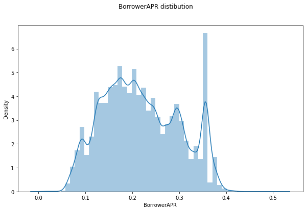

```python
plt.figure(figsize=(10,6))
plt.suptitle("BorrowerAPR distibution")
sb.distplot(new_df['BorrowerAPR']);
```

La distribution du taux de distribution annuel des emprunteurs est multimodale avec plusieurs pics.

## Corrélation entre variables

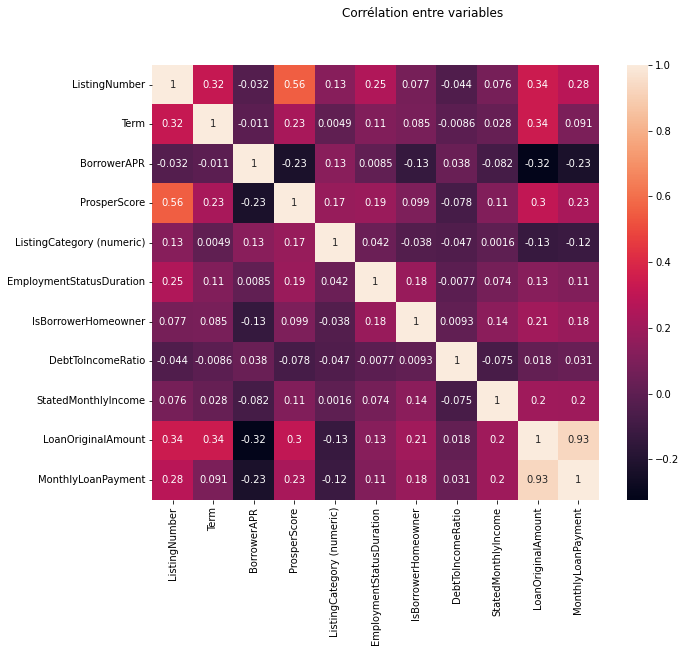

```python
plt.figure(figsize = (10, 8))
sb.heatmap(new_df.corr(), annot=True)
plt.suptitle("Corrélation entre variables");
```

Je vais éxplorer 3 relations entre deux variables qui sont :

```
BorrowerAPR vs prosperScore
BorrowerAPR vs LoanOriginalAmount
BorrowerAPR vs MonthlyLoanPayment
```

## BorrowerAPR vs prosperScore

> You should have at least three visualizations in your presentation, but feel free to add more if you'd like!

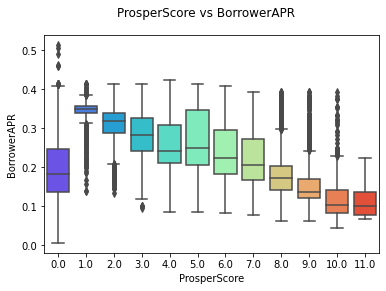

```python
sb.boxplot(x='ProsperScore',y='BorrowerAPR',data=new_df,palette='rainbow')
plt.suptitle("ProsperScore vs BorrowerAPR");
```

En global plus le score grandit plus le taux diminue

## BorrowerAPR vs LoanOriginalAmount

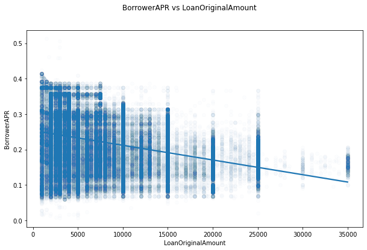

```python
plt.figure(figsize = [10, 6])
sb.regplot(x = 'LoanOriginalAmount' , y = 'BorrowerAPR', data = new_df, scatter_kws={'alpha':0.01})
plt.suptitle("BorrowerAPR vs LoanOriginalAmount");
```

Plus le montant du prêt obtenu est élevé, plus le taux annuel effectif global de l'emprunteur est faible

## BorrowerAPR vs MonthlyLoanPayment

[figure not shown]

```python
plt.figure(figsize = [10, 6])
plt.xlim([0,1500])
sb.regplot(x = 'MonthlyLoanPayment' , y = 'BorrowerAPR', data = new_df, scatter_kws={'alpha':0.01})
plt.suptitle("MonthlyLoanPayment vs LoanOriginalAmount");
```

Plus La mensualité prévue du prêt obtenu est élevé, plus le taux annuel effectif global de l'emprunteur est faible

## Term vs LoanOriginalAmount vs BorrowerAPR

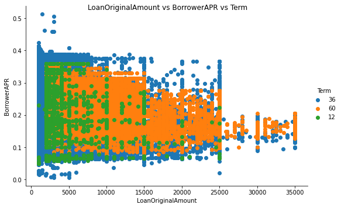

```python
val = sb.FacetGrid(data = new_df, hue = 'Term',hue_order = new_df.Term.value_counts().index, size = 5, aspect = 1.5)
val.map(plt.scatter, 'LoanOriginalAmount', 'BorrowerAPR')
val.add_legend()
plt.suptitle("LoanOriginalAmount vs BorrowerAPR vs Term");
```

Les prêts à terme de 36 mois ont un pourcentage de taux annuel des emprunteurs compris entre 0 et 0,4 avec quelques valeurs aberrantes allant à 0,5, les prêts à terme de 60 mois sont davantage concentrés sur les montants de prêt les plus élevés et les BorrowerAPR entre 0,1 et 0,35, tandis que la durée du prêt de 12 mois est principalement pour des montants de prêt inférieurs avec un BorrowerAPR entre 0 et 0,35.

### Submission

If you are using classroom workspace, you can choose from the following two ways of submission:

1. **Submit from the workspace**. Make sure you have removed the example project from the /home/workspace directory. You must submit the following files:
   - Part_I_notebook.ipynb
   - Part_I_notebook.html or pdf
   - Part_II_notebook.ipynb
   - Part_I_slides.html
   - README.md
   - dataset (optional)
1. **Submit a zip file on the last page of this project lesson**. In this case, open the Jupyter terminal and run the command below to generate a ZIP file.

   ```
   zip -r my_project.zip .
   ```

   The command abobve will ZIP every file present in your /home/workspace directory. Next, you can download the zip to your local, and follow the instructions on the last page of this project lesson.